# sp17hw04_solution

Piyali Das

April 2, 2017

We will be using the same prostate data used in the previous homework assignment. The data can be downloaded from the file ProstateData.zip from the Carmen web site course. 1.Let’s use naive Bayes to predict normal and tumor samples. a. Create an object with Normal and Tumor Samples. How many probes are there? How many samples of each type are there?

```r
load(file.path("ProstateData", "expression.data.rda"))
load(file.path("ProstateData", "clinical.info.rda"))
load(file.path("ProstateData", "gene.info.rda"))

xt <- which(clinical.info$Status == "N") # all Normal
xl <- which(clinical.info$Status == "T") # all Tumor
subdata <- expression.data[, c(xl, xt)]
subclin <- clinical.info[c(xl, xt),]
subclin$Status <- factor(subclin$Status)
nrow(subdata)
```

```
## [1] 28947
```

```r
nrow(clinical.info[clinical.info$Status == "N",])
```

```
## [1] 41
```

```r
nrow(clinical.info[clinical.info$Status == "T",])
```

```
## [1] 62
```

*There are 28,947 probes, 41 normal samples, and 62 tumor samples.*

2. While we can run the model using all our data, we may not need all the data to come up with a predictive model. Remove probes that do not match a gene. Then calculate fold changes (mean log2 expression for tumor samples minus log2 mean expression for normal samples) for the remaining probes and draw a histogram of the log2 mean expressions.

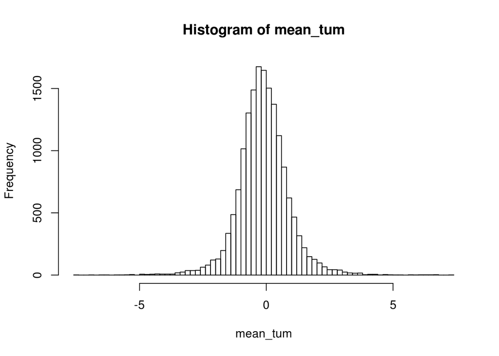

```r
#samps_scaled = apply(subdata, MARGIN = 2, FUN = function(X) (X - min(subdata))/diff(range(subdata)))
gene <- subdata[which(!gene.info$Gene.Symbol==""),]   ##gene.info[!gene.info$Gene.Symbol=="",]
tum_samp <- gene[,which(subclin$Status == "T")]
norm_samp <- gene[,which(subclin$Status == "N")]
mean_tum <-  rowMeans(tum_samp)
mean_norm <-  rowMeans(norm_samp)
fold <- mean_tum - mean_norm
hist(mean_tum, breaks = 100)
```

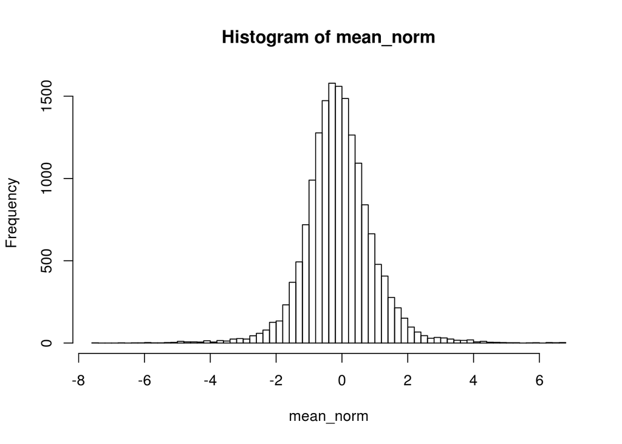

```r
hist(mean_norm, breaks = 100)
```

Now create 3 separate matrices: the top 5 probes showing the largest fold changes (in either direction); the top 1000 probes showing the largest fold changes; the top 5 probes showing the largest fold changes, and add the 200 probes that show the least amount of fold change.

```r
sortedfold <- sort(abs(fold), decreasing = TRUE)
vec <- sortedfold[1:5]
mat5 <- gene[names(vec),]
vec1 <- sortedfold[1:1000]
mat1000 <- gene[names(vec1),]
incr <- sort(abs(fold))
vec2 <- incr[1:200]
matx <- gene[names(vec),]
maty <- gene[names(vec2),]
matcomb <- rbind(matx, maty)
```

3. Apply naiveBayes to each set (top 5 probes, top 1000 probes, top 5 probes + bottom 200 probes) to predict N or T status. For each model, predict your status on the original data. Calculate specificity and sensitivity for each model and compare. What do you observe?

```r
if (!require(e1071)) {
  install.packages("e1071")
  library(e1071)
}
model1 <- naiveBayes(x = t(mat5) , y = subclin$Status)
class(model1)
```

```
## [1] "naiveBayes"
```

```r
#summary(model1)
#print(model1)
mypred1 <- predict(model1,t(gene))
table(data.frame(Pred=mypred1,Truth=subclin$Status))
```

```
##     Truth
## Pred  N  T
##    N 40  3
##    T  1 59
```

*The specificity for the 1st model is 59/62 = 0.951 and sensitivity is 40/41 = 0.975*

```r
model2 <- naiveBayes(x = t(mat1000) , y = subclin$Status)
class(model2)
```

```
## [1] "naiveBayes"
```

```r
mypred2 <- predict(model2,t(gene))
table(data.frame(Pred=mypred2,Truth=subclin$Status))
```

```
##     Truth
## Pred  N  T
##    N 41  2
##    T  0 60
```

*The specificity for the 2nd model is 60/62 = 0.967 and sensitivity is 41/41 = 1*

```r
model3 <- naiveBayes(x = t(matcomb) , y = subclin$Status)
class(model3)
```

```
## [1] "naiveBayes"
```

```r
mypred3 <- predict(model3,t(gene))
table(data.frame(Pred=mypred3,Truth=subclin$Status))
```

```
##     Truth
## Pred  N  T
##    N 41  1
##    T  0 61
```

*The specificity for the 3rd model is 61/62 = 0.983 and sensitivity is 41/41 = 1* *In each case its seen that the specificity is less than the sensitivity. Also when the top 5 probes, top 1000 probes are compared it shows that using the later one is more worthy*

2.Do the same as 1c) but with LASSO. This is a 4-step process (you may want to write a function to do this since you’ll need to run 3 times, once for each data subset): a. Use a 3-fold cross-validation to optimize the value of lambda (as we did in class). Plot the result.

```r
if (!require(glmnet)) {
  install.packages("glmnet")
  library(glmnet)
}
set.seed(1234)
cv.lasso <- cv.glmnet(x = t(mat5), y = subclin$Status, nfolds=3,
                      family='binomial', alpha=1, parallel=TRUE, standardize=TRUE,
                      type.measure='auc')
```

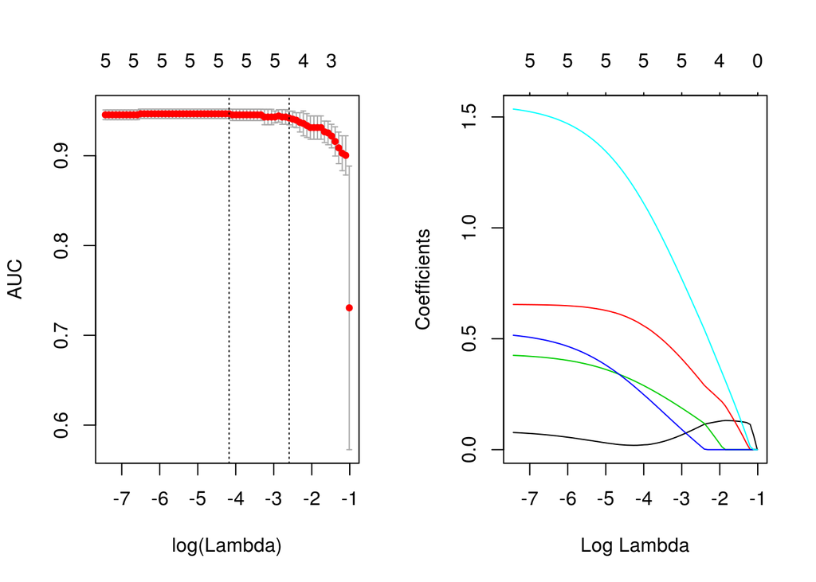

```r
par(mfrow=c(1,2))
plot(cv.lasso)
plot(cv.lasso$glmnet.fit, xvar="lambda", label=TRUE)
```

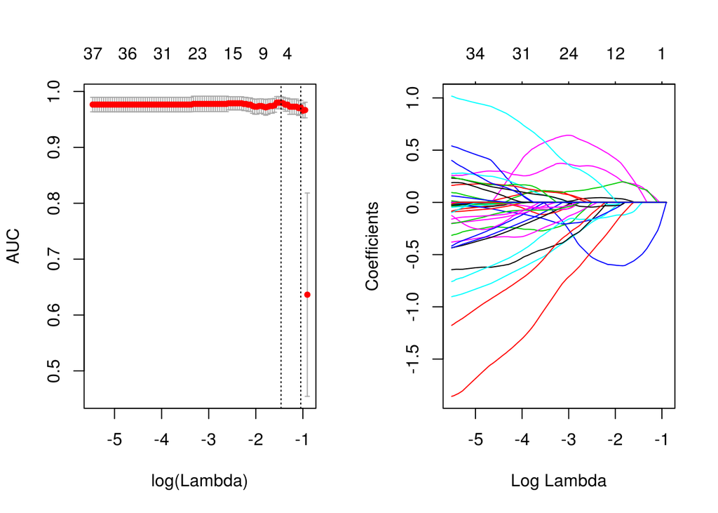

```r
set.seed(1234)
cv1.lasso <- cv.glmnet(x = t(mat1000), y = subclin$Status, nfolds=3,
                      family='binomial', alpha=1, parallel=TRUE, standardize=TRUE,
                      type.measure='auc')
par(mfrow=c(1,2))
plot(cv1.lasso)
plot(cv1.lasso$glmnet.fit, xvar="lambda", label=TRUE)
```

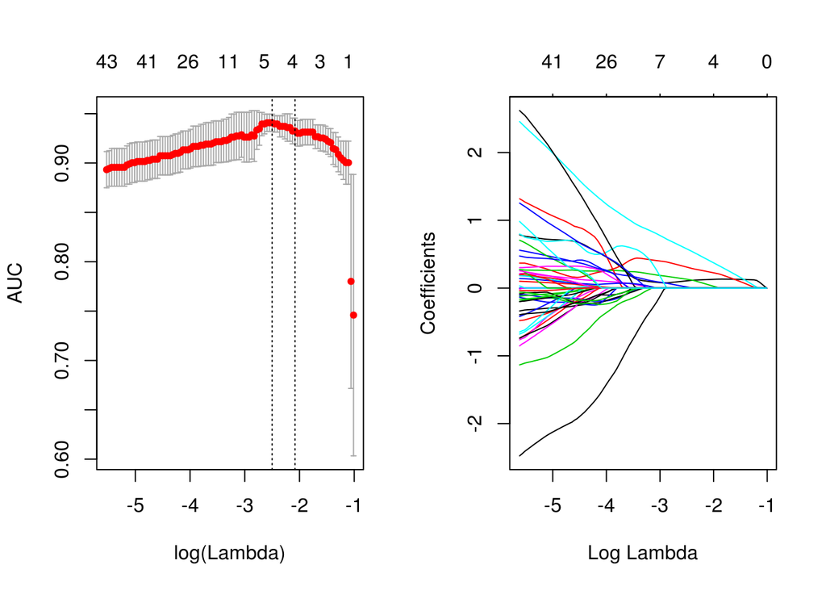

```r
set.seed(1234)
cv2.lasso <- cv.glmnet(t(matcomb),subclin$Status, nfolds=3,
                      family='binomial', alpha=1, parallel=TRUE, standardize=TRUE,
                      type.measure='auc')
par(mfrow=c(1,2))
plot(cv2.lasso)
plot(cv2.lasso$glmnet.fit, xvar="lambda", label=TRUE)
```

b.Run a lasso model on the entire data, using the optimal lambda (hint: use the function glmnet() and set the paramter lambda to the optimal lambda you get from the previous CV model - lambda.min slot from result of previous step)

```r
binary <- rep(0, length(subclin$Status))
binary[which(subclin$Status == "T")] = 1
entire5 <- glmnet(x = t(gene), y = binary, lambda = cv.lasso$lambda.min)
entire1000 <- glmnet(x = t(gene), y = binary, lambda = cv1.lasso$lambda.min)
entirecomb <- glmnet(x = t(gene), y = binary, lambda = cv2.lasso$lambda.min)
```

3. Make predictions of T and N using predict. (predict() will behave differently now that it’s taking the output of glmnet(), so you may have to make the predictions yourself, based on the percent likelihood of each class. For example, if % likelihood >=0.5, then you predict Tumor, if it’s <-.5, you predict Normal)

```r
cv.lasso.pr = predict(entire5,type="response",newx=as.matrix(t(gene)))
# pred1 <- prediction(cv.lasso.pr, subclin$Status)
# perflasso1 <- performance(pred1, measure = "tpr", x.measure = "fpr")

lasso_pred <- rep("N", length(subclin$Status))
lasso_pred[which(cv.lasso.pr >= 0.5)] = "T"

cv.lasso.pr1 = predict(entire1000,type="response",newx=as.matrix(t(gene)))
# pred2 <- prediction(cv.lasso.pr1, subclin$Status)
# perflasso1 <- performance(pred2, measure = "tpr", x.measure = "fpr")

lasso_pred1 <- rep("N", length(subclin$Status))
lasso_pred1[which(cv.lasso.pr1>=0.5)] = "T"

cv.lasso.pr2 = predict(entirecomb,type="response",newx=as.matrix(t(gene)))
# pred3 <- prediction(cv.lasso.pr2, subclin$Status)
# perflasso1 <- performance(pred3, measure = "tpr", x.measure = "fpr")

lasso_pred2 <- rep("N", length(subclin$Status))
lasso_pred2[which(cv.lasso.pr2>=0.5)] = "T"
```

4. Calculate specificity and sensitivity. As in 1c) compare and contrast results. What do you observe? Does the choice of lambda avoid overfitting when the 5 most altered genes and the 200 least altered genes are used?

```r
table(data.frame(Pred = lasso_pred, Truth = subclin$Status))
```

```
##     Truth
## Pred  N  T
##    N 41  0
##    T  0 62
```

```r
table(data.frame(Pred = lasso_pred1, Truth = subclin$Status))
```

```
##     Truth
## Pred  N  T
##    N 35  2
##    T  6 60
```

```r
table(data.frame(Pred = lasso_pred2, Truth = subclin$Status))
```

```
##     Truth
## Pred  N  T
##    N 41  2
##    T  0 60
```

3.Let’s apply random forests now on each set (hint: if you look at the slots of the randomForest output, you may find your confusion matrix ready for you to calculate sensitivity and specificity!) a. Compare and contrast predictions on each set as in previous questions.

```r
if (!require(randomForest)) {
  install.packages("randomForest")
  library(randomForest)
}
status = t(as.data.frame(subclin$Status)) #subclin$Status <- factor(subclin$Status)
colnames(status) = colnames(mat5)
rownames(status) = "Status"

top5 = as.data.frame(t(rbind(mat5,status)))
for (i in 1:(dim(top5)[2] - 1)){
  top5[,i] = as.numeric(as.character(top5[,i]))
}
myrf5 = randomForest(Status ~ ., data = top5, importance = TRUE, proximity=TRUE)
print(myrf5)
```

```
##
## Call:
##  randomForest(formula = Status ~ ., data = top5, importance = TRUE,      proximity = TRUE)
##                Type of random forest: classification
##                      Number of trees: 500
## No. of variables tried at each split: 2
##
##         OOB estimate of  error rate: 5.83%
## Confusion matrix:
##    N  T class.error
## N 37  4  0.09756098
## T  2 60  0.03225806
```

```r
top1000 = as.data.frame(t(rbind(mat1000,status)))
for (i in 1:(dim(top1000)[2] - 1)){
  top1000[,i] = as.numeric(as.character(top1000[,i]))
}
myrf1000 = randomForest(Status ~ ., data = top1000, importance = TRUE, proximity=TRUE)
print(myrf1000)
```

```
##
## Call:
##  randomForest(formula = Status ~ ., data = top1000, importance = TRUE,      proximity = TRUE)
##                Type of random forest: classification
##                      Number of trees: 500
## No. of variables tried at each split: 31
##
##         OOB estimate of  error rate: 1.94%
## Confusion matrix:
##    N  T class.error
## N 41  0  0.00000000
## T  2 60  0.03225806
```

```r
top_comb = as.data.frame(t(rbind(as.data.frame(matcomb),status)))
for (i in 1:(dim(top_comb)[2] - 1)){
  top_comb[,i] = as.numeric(as.character(top_comb[,i]))
}
myrf_comb = randomForest(Status ~ ., data = top_comb, importance = TRUE, proximity=TRUE)
print(myrf_comb)
```

```
##
## Call:
##  randomForest(formula = Status ~ ., data = top_comb, importance = TRUE,      proximity = TRUE)
##                Type of random forest: classification
##                      Number of trees: 500
## No. of variables tried at each split: 14
##
##         OOB estimate of  error rate: 6.8%
## Confusion matrix:
##    N  T class.error
## N 36  5  0.12195122
## T  2 60  0.03225806
```

2. For your random forest model built with the top 5 altered genes + 200 least altered genes, retrieve the importance measures, and plot the top 20 (using MeanDecreaseGini importance measure 4th col, rows 1:20). Is it obvious that the top 5 altered genes are most important for predictions?

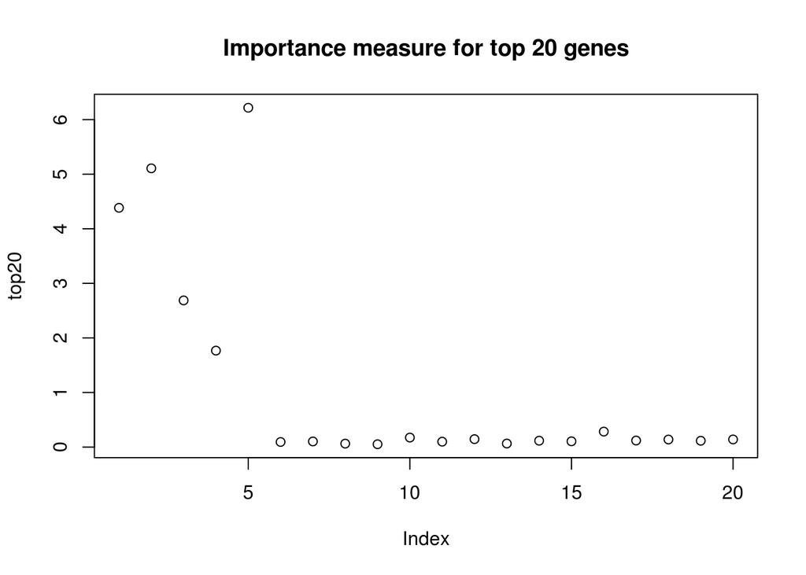

```r
x <- importance(myrf_comb)
top20 <- x[1:20,4]
plot(top20, main = "Importance measure for top 20 genes") #mat5 <- gene[names(vec),]
```

*Yes it is obvious that the top 5 genes are most obvious for the observations as it is clearly seen in the plot*

4.Compare and contrast how naive Bayes, LASSO, and random forests perform on predicting each dataset. *Naive Bayes assumes that the attributes are independent but in reality they are not. So ideally it should performs worst out of the 3 models in question. But this varies from dataset to dataset. One observation was that the training and test dataset used in LASSO needs to be of the same dimension which is not the ideal case always. The more sensitive a test, the less likely an individual with a negative test will have the disease. The more specific the test, the less likely an individual with a positive test will be free from disease and the greater the positive predictive value. Random forest does not seem to perform good with the datasets given. LASSO seems to perform overall better in my opinion.*

5.Practically, we always want to cross-validate, to ensure that our model is not overfit. We will do this two ways: 1) we will cross-validate the model only; 2) we will cross-validate the feature selection (based on fold change for this exercise) and the model. a. Using your favorite model (e.g. LASSO, naive Bayes, or random forest), run a 3-fold cross-validation using the top 5 most altered genes + 200 least altered genes, as you defined them previously. Draw an ROC plot that shows the changes sensitivity/specificity for each fold, and for the model that uses all the data (e.g. no cross-validation). Which models perform best? *I have used Naive Bayes model here.*

```r
if (!require(ROCR)) {
  install.packages("ROCR")
  library(ROCR)
}
if (!require(caret)) {
  install.packages("caret")
  library(caret)
}
model = train(t(matcomb),subclin$Status,'nb',
              trControl=trainControl(method='cv',number=3,savePredictions=T))
Prediction <- function(mod) {
    folds <- unique(mod$pred$Resample)
    specificity <- NULL
    sensitivity <- NULL
    for (i in 1:length(folds)) {
      temp <- table(mod$pred[which(mod$pred$Resample==folds[i]),2:1])
      sensitivity=c(sensitivity,temp[2,2]/(temp[2,2]+temp[2,1]))
      specificity = c(specificity,temp[1,1]/(temp[1,1]+temp[1,2]))
    }
    return(data.frame(specificity=specificity,sensitivity=sensitivity))
}
store <- Prediction(model)
store
```

```
##   specificity sensitivity
## 1   0.6153846   0.9250000
## 2   0.7142857   1.0000000
## 3   0.6785714   0.8809524
```

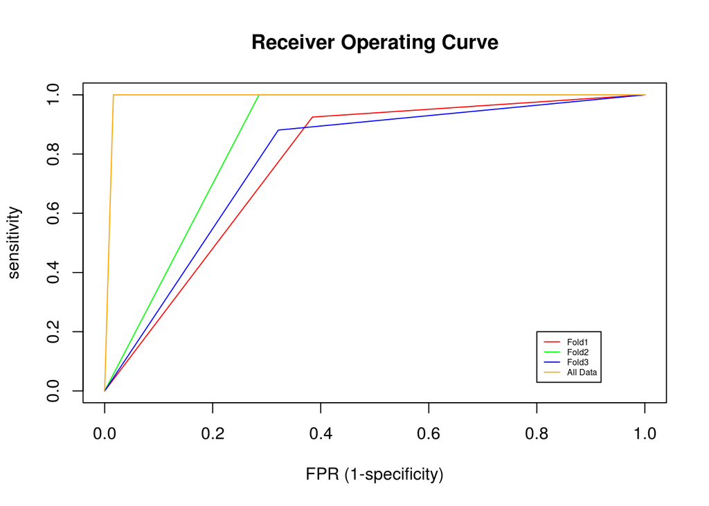

```r
colorplate=c("red","green","blue","orange")
plot(c(0,(1-store[1,1]),1),c(0,store[1,2],1), type="l", col=colorplate[1], main="Receiver Operating Curve",
     xlab="FPR (1-specificity)",ylab="sensitivity",xlim=c(0,1),ylim=c(0,1))
for (i in 2:3) {
  lines(c(0,(1-store[i,1]),1),c(0,store[i,2],1),col=colorplate[i])
}
###Creating line for all data; Sensitivity was 41/41, Specificity was 61/62
lines(c(0,(1-61/62),1),c(0,41/41,1),col=colorplate[4])
legend(0.8,0.2,c(paste0("Fold",1:3),"All Data"),lty=1,cex=0.5,col=colorplate)
```

2. Using your favorite model, create a function that performs a 3-fold cross-validation on the variable selection and model. For each fold, you then need to recreate your top 5 most altered genes + least 200 altered genes. Keep track of the top 5 most altered genes for each fold and print the 5 genes used for each fold. Are these consistent? As in a, draw an ROC curve contrasting each fold change vs the entire model. *the top 5 most altered genes for the 1st 2 folds are same whereas in the 3rd fold few genes are similar and rest are now. And this is as per our expectation.*

```r
set.seed(1234)
###For fold 1
x <- nrow(gene)*2/3
traindata <- gene[1:x,]
testdata <- gene[x:nrow(gene),]
dim(traindata);
```

```
## [1] 11066   103
```

```r
dim(testdata)
```

```
## [1] 5534  103
```

```r
samp_tum <- traindata[,which(subclin$Status == "T")]
samp_nor <- traindata[,which(subclin$Status == "N")]
tum_mean <-  rowMeans(samp_tum)
nor_mean <-  rowMeans(samp_nor)
fold_change <- tum_mean - nor_mean
foldsorted <- sort(abs(fold_change), decreasing = TRUE)
vec_5 <- foldsorted[1:5]
incrfold <- sort(abs(fold_change))
vec_200 <- incrfold[1:200]
mat5 <- traindata[names(vec_5),]
mat200 <- traindata[names(vec_200),]
newset <- rbind(mat5, mat200)
rownames(newset[1:5,])
```

```
## [1] "X23250" "X1192"  "X1864"  "X25512" "X4333"
```

```r
modelnb <- naiveBayes(t(traindata), subclin$Status)
myprednb <- predict(modelnb,t(testdata))
table(data.frame(Pred=myprednb,Truth=subclin$Status))
```

```
##     Truth
## Pred  N  T
##    N 28 19
##    T 13 43
```

*Specificity of 1st fold = 43/62=0.69 and sensitivity = 28/41=0.68*

```r
###For fold 2
x1 <- nrow(gene)*1/3
traindata1 <- gene[x1:nrow(gene),]
testdata1 <- gene[1:x1,]
dim(traindata1);
```

```
## [1] 11067   103
```

```r
dim(testdata1)
```

```
## [1] 5533  103
```

```r
samp_tum1 <- traindata[,which(subclin$Status == "T")]
samp_nor1 <- traindata[,which(subclin$Status == "N")]
tum_mean1 <-  rowMeans(samp_tum1)
nor_mean1 <-  rowMeans(samp_nor1)
fold_change1 <- tum_mean1 - nor_mean1
foldsorted1 <- sort(abs(fold_change1), decreasing = TRUE)
vec_51 <- foldsorted1[1:5]
incrfold1 <- sort(abs(fold_change1))
vec_2001 <- incrfold1[1:200]
mat51 <- traindata[names(vec_51),]
mat2001 <- traindata[names(vec_2001),]
newset1 <- rbind(mat51, mat2001)
rownames(newset1[1:5,])
```

```
## [1] "X23250" "X1192"  "X1864"  "X25512" "X4333"
```

```r
modelnb1 <- naiveBayes(t(traindata1), subclin$Status)
myprednb1 <- predict(modelnb1,t(testdata1))
table(data.frame(Pred=myprednb1,Truth=subclin$Status))
```

```
##     Truth
## Pred  N  T
##    N  0  0
##    T 41 62
```

*Specificity of 2nd fold = 62/62= 1 and sensitivity = 0/41= 0*

```r
set.seed(1234)
###For fold 3
x2 <- nrow(gene)*1/3
x3 <- nrow(gene)*2/3
traindata2 <- rbind(gene[1:x2,],gene[x3:nrow(gene),])
testdata2 <- gene[x2:x3,]
dim(traindata2);
```

```
## [1] 11067   103
```

```r
dim(testdata2)
```

```
## [1] 5534  103
```

```r
samp_tum2 <- traindata2[,which(subclin$Status == "T")]
samp_nor2 <- traindata2[,which(subclin$Status == "N")]
tum_mean2 <-  rowMeans(samp_tum2)
nor_mean2 <-  rowMeans(samp_nor2)
fold_change2 <- tum_mean2 - nor_mean2
foldsorted2 <- sort(abs(fold_change2), decreasing = TRUE)
vec_52 <- foldsorted2[1:5]
incrfold2 <- sort(abs(fold_change2))
vec_2002 <- incrfold2[1:200]
mat52 <- traindata2[names(vec_52),]
mat2002 <- traindata2[names(vec_2002),]
newset2 <- rbind(mat52, mat2002)
rownames(newset2[1:5,])
```

```
## [1] "X35441" "X1192"  "X1864"  "X34181" "X4333"
```

```r
modelnb2 <- naiveBayes(t(traindata2), subclin$Status)
myprednb2 <- predict(modelnb2,t(testdata2))
table(data.frame(Pred=myprednb2,Truth=subclin$Status))
```

```
##     Truth
## Pred  N  T
##    N 35 20
##    T  6 42
```

*Specificity of 3rd fold = 42/62= 0.67 and sensitivity = 35/41= 0.85*

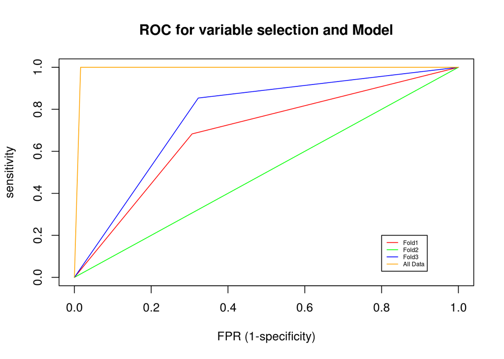

```r
plot(c(0,(1-43/62),1),c(0,28/41,1), type="l", col=colorplate[1], main="ROC for variable selection and Model",
     xlab="FPR (1-specificity)",ylab="sensitivity",xlim=c(0,1),ylim=c(0,1))
lines(c(0,(1-1),1),c(0,0,1),col=colorplate[2])
lines(c(0,(1-42/62),1),c(0,35/41,1),col=colorplate[3])
lines(c(0,(1-61/62),1),c(0,41/41,1),col=colorplate[4])
legend(0.8,0.2,c(paste0("Fold",1:3),"All Data"),lty=1,cex=0.5,col=colorplate)
```

3. Compare and contrast a and b. Which is the most appropriate approach? *Approach ‘a’ seems to be a better approach. In this dataset both the tumor and normal samples are seen to be clustered together. So when we partition the dataset to create test data and training data, few tumor types are completely vanishing. That means we loose some significant information. Hence approach ‘b’ does not perform well.*